# Final Project: GLANCE Study

Tuesday, March 10, 2015

## Setting up some options

Let's first turn on the cache for increased performance and improved styling

```r
# Set some global knitr options
library("knitr")
opts_chunk$set(tidy=TRUE, size='tiny',tidy.opts=list(blank=FALSE, width.cutoff=80), cache=TRUE, messages=FALSE)
```

## Reference

**Navarro S, White E, Kantor ED, Zhang Y, Rho J, Song X, Milne GL, Lampe PD, Lampe JW. Randomized trial of glucosamine and chondroitin supplementation on inflammation and oxidative stress biomarkers and plasma proteomics profiles in healthy humans. PLoS One. 2015; 10(2):e0117534**

## Outline

- Background
- Study Design and Data Collection
- Statistical Analysis Plan
- Data Analysis and Results
- Limitations
- Conclusions

## Background

**Glucosamine and Chondroitin (G&C)**

- One of the most popular dietary supplements in the US
- Mostly taken for osteoarthritis (OA)
- Associated with a 27-35% lower incidence of colorectal cancer, a 26-28% lower incidence of lung cancer, 17% lower overall mortality, and a 13% lower cancer mortality.
- Safe supplements, with no known major adverse side effects.
- Regular dose
- 1500 mg/d glucosamine hydrochloride (GHCl) + 1200 mg/d chondroitin sulfate (CS)

## Background

**Mechanisms of G&C on cancer prevention**

- Several lines of evidence from *in vitro* and preclinical studies support a possible role for G&C in reducing inflammation.
- Potentially through inhibition of nuclear factor kappa B pathway.
- No human intervention trials have been evaluated the effect of G&C on reducing inflammation or altering other pathways in healthy individuals

## Study Design

- Randomized, double-blinded, placebo-controlled crossover trial
- Ranomized on the order of treatment or placebo period
- Each intervention period lasted 28 days with a 28 day washout period in-between

## Participants

- 18 subjects: 9 males and 9 females
- Healthy, overweight(25<BMI<=32.5), non-smoking, aged 20-55 years individuals in the greater Seattle area.
- Strict exclusion criteria (e.g. medical history, medication use, large weight change, alcohol intake, supplemental use, vegetarian dietary and abnormal laboratory values)

## Data collection

- Blood samples were collected after each 28-day intervention period in the morning after a minimum of a 12-hour overnight fast.
- Blood was drawn into a tube containing EDTA for plasma. All samples were aliquoted and stored at -80 degree C.

## Proteomics Analysis

- Plasma samples were evaluated on a customized antibody array populated with ~3,000 full-length antibodies, printed in triplicates.
- Protein (200 g) from a pool of albumin and IgG-depleted plasma were labeled with Cy5. Each sample was combined with reference sample labeled with Cy3.
- Unbound proteins were removed by washing and the slides scanned for Cy3 and Cy5 fluorescence in an Axon Genepix 4000B scanner.
- The Cy5/Cy3 ratio determined the relative concentration of protein compared to reference.
- Most (>85%) antibodies on the array had coefficients of variation, for triplicates, of less than 10%. Antibodies with CV>10% were excluded for further analysis.

## Array Analysis and Normalization

- The array image was scanned using a GenePix 4000B (Axon Instruments) scanner.
- For each antibody, fold-change of the signal (red channel) was compared to the reference (green channel) after background correction, the ratio noted as M value.
- Experimental variation was normalized using within-array print-tip loess and between-array quartile normalization.
- Triplicate features were summarized using their median. M values were standardized such that the mean value and standard deviation of the placebo groups were set to zero and one, respectively.
- After all processing, data were available for analysis on a total of 2938 antibodies.

## Statistical Analysis

**Overview of data**

- We have 18 treatment and 18 placebo samples
- We delete any genes with more than 50% missing values
- Each has data on a 2938 antibodies
- About 1100 of the antibodies are duplicates

*Would this be of concern? (Stay tuned!)*

## Statistical Analysis Plans

**Plan 1. Replicate the reported results**

- Using linear regression to adjust for batch effects
- Paired t-test comparing treatment and placebo
- GSEA analysis using Wilcoxon Test

## Statistical Analysis Plans

**Plan 2. Alternative analysis plan**

- Clean duplicated antibodies
- (Same as plan 1) Using linear regression to adjust for batch effects
- Moderated T test using R Limma package
- GSEA using GEGG and GO pathway databases and CAMERA

## Statistical Analysis Results -Plan 1

- Batch effects check(graph)

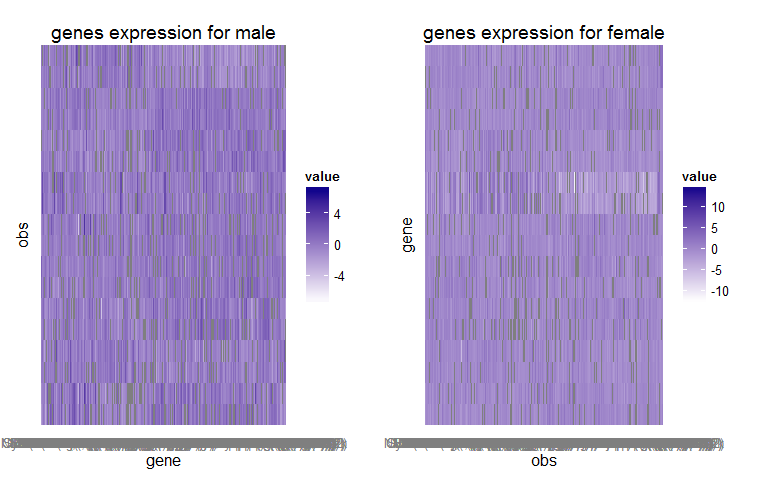

## Statistical Analysis Results -Plan 1

- Batch effects check(multiple tests)

```r
round(Table, digits = 3)
```

```
##                      Hybrid.day   box position gender
## prop(p-value<.05)         0.316 0.525    0.016  0.316
## prop(bonferroni<.05)      0.028 0.016    0.000  0.028
```

## Statistical Analysis Results -Plan 1

- Using linear regression to adjust for batch effects *m~case+Hybrid.day+box+position+gender*
- Paired t-test comparing treatment and placebo
- The threshold value for q value and bonferroni test is 0.001.

## Statistical Analysis Results -Plan 1

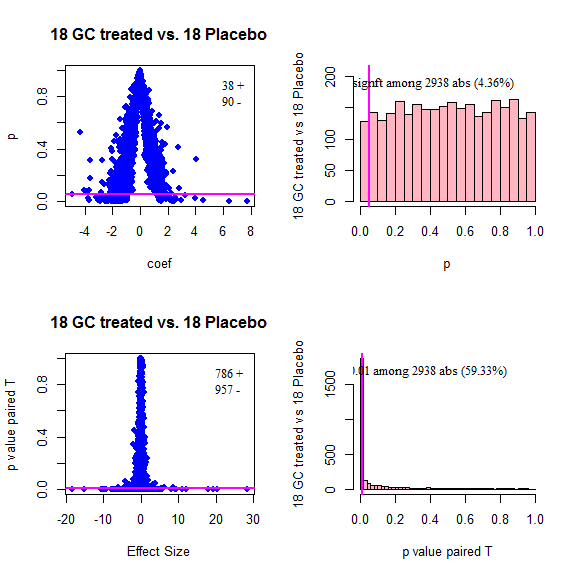

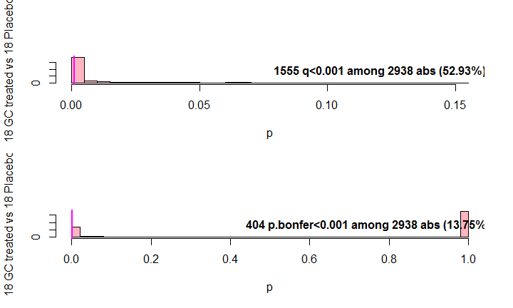

## Statistical Analysis Results -Plan 1

```r
head(out)
```

```
##                               Name effect.size          p.t       qvalue
## 2901 Plate9_O12_CEACAM1(Std)_Sigma   -2.324371 2.288379e-14 0.0001746329
## 511        Plate2_A22_ITGA5 _Abcam   -1.741159 2.665558e-14 0.0001746329
## 1570           Plate5_M9_itgb4_R&D   -1.962622 6.898708e-14 0.0001746329
## 1373        Plate5_E10_C1orf38_SDI    4.036857 1.141251e-13 0.0001746329
## 120         Plate1_F12_MUC3B_Aviva    4.140094 3.204087e-13 0.0001746329
## 819        Plate2_P5_GADD45A_Abcam   -1.137069 4.832897e-13 0.0001746329
##            bonfer
## 2901 6.723256e-11
## 511  7.831409e-11
## 1570 2.026840e-10
## 1373 3.352996e-10
## 120  9.413608e-10
## 819  1.419905e-09
```

## Statistical Analysis Results -Plan 1

- GSEA analysis using Wilcoxon Test
- a Wilcoxon test to test for diserences in the distribution of p values between SNPs within the gene set under test and a control set of SNPs.
- The Wilcoxon signed-rank test is a non-parametric statistical hypothesis test used when comparing two related samples, matched samples, or repeated measurements on a single sample to assess whether their population mean ranks differ

## Statistical Analysis Results -Plan 1

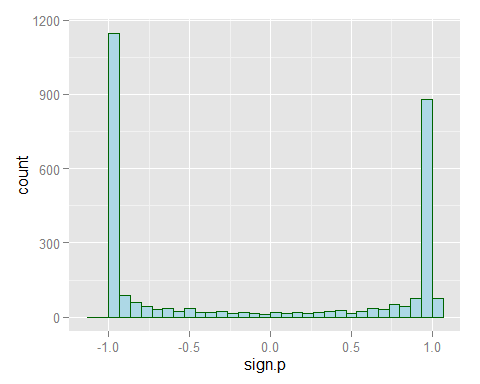

## Statistical Analysis Results -Plan 1

- GSEA analysis using GO pathways

```
## [1] "Number of unique genes:" "1272"
```

```
## [1] "Number of Gene Sets:" "1353"
```

```
## NUCLEOPLASM
##          25
```

```
## NUCLEOPLASM
##           8
```

```
## [1] 33
```

## Statistical Analysis Results -Plan 1

- GSEA analysis using GO pathways

```r
head(gene.set)
```

```
##                                                 MasterGroup
## EXTRACELLULAR_REGION                                     23
## NUCLEOPLASM                                               1
## INSOLUBLE_FRACTION                                       47
## GTPASE_REGULATOR_ACTIVITY                               777
## ER_GOLGI_INTERMEDIATE_COMPARTMENT                       112
## RNA_POLYMERASE_II_TRANSCRIPTION_FACTOR_ACTIVITY         779
##                                                                                         GS.Name
## EXTRACELLULAR_REGION                                                       EXTRACELLULAR_REGION
## NUCLEOPLASM                                                                         NUCLEOPLASM
## INSOLUBLE_FRACTION                                                           INSOLUBLE_FRACTION
## GTPASE_REGULATOR_ACTIVITY                                             GTPASE_REGULATOR_ACTIVITY
## ER_GOLGI_INTERMEDIATE_COMPARTMENT                             ER_GOLGI_INTERMEDIATE_COMPARTMENT
## RNA_POLYMERASE_II_TRANSCRIPTION_FACTOR_ACTIVITY RNA_POLYMERASE_II_TRANSCRIPTION_FACTOR_ACTIVITY
##                                                                                                                                      GS.descrip
## EXTRACELLULAR_REGION                                                       http://www.broadinstitute.org/gsea/msigdb/cards/EXTRACELLULAR_REGION
## NUCLEOPLASM                                                                         http://www.broadinstitute.org/gsea/msigdb/cards/NUCLEOPLASM
## INSOLUBLE_FRACTION                                                           http://www.broadinstitute.org/gsea/msigdb/cards/INSOLUBLE_FRACTION
## GTPASE_REGULATOR_ACTIVITY                                             http://www.broadinstitute.org/gsea/msigdb/cards/GTPASE_REGULATOR_ACTIVITY
## ER_GOLGI_INTERMEDIATE_COMPARTMENT                             http://www.broadinstitute.org/gsea/msigdb/cards/ER_GOLGI_INTERMEDIATE_COMPARTMENT
## RNA_POLYMERASE_II_TRANSCRIPTION_FACTOR_ACTIVITY http://www.broadinstitute.org/gsea/msigdb/cards/RNA_POLYMERASE_II_TRANSCRIPTION_FACTOR_ACTIVITY
##                                                 GS.num.gene num.gene.in
## EXTRACELLULAR_REGION                                    447         136
## NUCLEOPLASM                                             279          30
## INSOLUBLE_FRACTION                                       15           3
## GTPASE_REGULATOR_ACTIVITY                               125          20
## ER_GOLGI_INTERMEDIATE_COMPARTMENT                        24           4
## RNA_POLYMERASE_II_TRANSCRIPTION_FACTOR_ACTIVITY         182          28
##                                                 num.abprobe.in sig.pairt
## EXTRACELLULAR_REGION                                       222       139
## NUCLEOPLASM                                                 46        33
## INSOLUBLE_FRACTION                                           8         6
## GTPASE_REGULATOR_ACTIVITY                                   34        15
## ER_GOLGI_INTERMEDIATE_COMPARTMENT                           12        10
## RNA_POLYMERASE_II_TRANSCRIPTION_FACTOR_ACTIVITY             57        29
##                                                 sig.positive sig.negative
## EXTRACELLULAR_REGION                                      54           85
```

[output cut: 19 more lines]

## Statistical Analysis Results -Plan 1

- Repeat GSEA analysis using KEGG pathways

```
## [1] "Number of unique genes:" "890"
```

```
## [1] "Number of Gene Sets:" "178"
```

```
## KEGG_GLYCOLYSIS_GLUCONEOGENESIS
##                               8
```

```
## KEGG_GLYCOLYSIS_GLUCONEOGENESIS
##                              19
```

```
## [1] 27
```

## Statistical Analysis Results -Plan 1

- Repeat GSEA analysis using KEGG pathways

```r
head(gene.set)
```

```
##                                                MasterGroup
## KEGG_UBIQUITIN_MEDIATED_PROTEOLYSIS                     47
## KEGG_OXIDATIVE_PHOSPHORYLATION                           6
## KEGG_NOTCH_SIGNALING_PATHWAY                            57
## KEGG_HOMOLOGOUS_RECOMBINATION                           35
## KEGG_RNA_DEGRADATION                                    28
## KEGG_NATURAL_KILLER_CELL_MEDIATED_CYTOTOXICITY          77
##                                                                                       GS.Name
## KEGG_UBIQUITIN_MEDIATED_PROTEOLYSIS                       KEGG_UBIQUITIN_MEDIATED_PROTEOLYSIS
## KEGG_OXIDATIVE_PHOSPHORYLATION                                 KEGG_OXIDATIVE_PHOSPHORYLATION
## KEGG_NOTCH_SIGNALING_PATHWAY                                     KEGG_NOTCH_SIGNALING_PATHWAY
## KEGG_HOMOLOGOUS_RECOMBINATION                                   KEGG_HOMOLOGOUS_RECOMBINATION
## KEGG_RNA_DEGRADATION                                                     KEGG_RNA_DEGRADATION
## KEGG_NATURAL_KILLER_CELL_MEDIATED_CYTOTOXICITY KEGG_NATURAL_KILLER_CELL_MEDIATED_CYTOTOXICITY
##                                                                                                                                    GS.descrip
## KEGG_UBIQUITIN_MEDIATED_PROTEOLYSIS                       http://www.broadinstitute.org/gsea/msigdb/cards/KEGG_UBIQUITIN_MEDIATED_PROTEOLYSIS
## KEGG_OXIDATIVE_PHOSPHORYLATION                                 http://www.broadinstitute.org/gsea/msigdb/cards/KEGG_OXIDATIVE_PHOSPHORYLATION
## KEGG_NOTCH_SIGNALING_PATHWAY                                     http://www.broadinstitute.org/gsea/msigdb/cards/KEGG_NOTCH_SIGNALING_PATHWAY
## KEGG_HOMOLOGOUS_RECOMBINATION                                   http://www.broadinstitute.org/gsea/msigdb/cards/KEGG_HOMOLOGOUS_RECOMBINATION
## KEGG_RNA_DEGRADATION                                                     http://www.broadinstitute.org/gsea/msigdb/cards/KEGG_RNA_DEGRADATION
## KEGG_NATURAL_KILLER_CELL_MEDIATED_CYTOTOXICITY http://www.broadinstitute.org/gsea/msigdb/cards/KEGG_NATURAL_KILLER_CELL_MEDIATED_CYTOTOXICITY
##                                                GS.num.gene num.gene.in
## KEGG_UBIQUITIN_MEDIATED_PROTEOLYSIS                    138          23
## KEGG_OXIDATIVE_PHOSPHORYLATION                         135           8
## KEGG_NOTCH_SIGNALING_PATHWAY                            47          22
## KEGG_HOMOLOGOUS_RECOMBINATION                           28           7
## KEGG_RNA_DEGRADATION                                    59           6
## KEGG_NATURAL_KILLER_CELL_MEDIATED_CYTOTOXICITY         137          43
##                                                num.abprobe.in sig.pairt
## KEGG_UBIQUITIN_MEDIATED_PROTEOLYSIS                        37        16
## KEGG_OXIDATIVE_PHOSPHORYLATION                             12         7
## KEGG_NOTCH_SIGNALING_PATHWAY                               32        19
## KEGG_HOMOLOGOUS_RECOMBINATION                              16         7
## KEGG_RNA_DEGRADATION                                       16         9
## KEGG_NATURAL_KILLER_CELL_MEDIATED_CYTOTOXICITY             72        43
##                                                sig.positive sig.negative
## KEGG_UBIQUITIN_MEDIATED_PROTEOLYSIS                      13            3
```

[output cut: 19 more lines]

## Statistical Analysis Results -Plan 2

- Clean duplicated antibodies
- we have 1892 genes and 36 samples

## Statistical Analysis Results -Plan 2

- (Same as plan 1) Using linear regression to adjust for batch effects

## Statistical Analysis Results -Plan 2

- Moderated T test using R Limma package

```r
# So we run everything in the orginal codes before paired t-test And we use limma
# instead of pairted t test to fit the model
mm <- model.matrix(~0 + id + case, data = info.temp)
mm <- mm[, -11]
mm <- mm[, -(19:24)]
fit <- lmFit(est.m, mm)
```

## Statistical Analysis Results -Plan 2

- Moderated T test using R Limma package

```r
ebay <- eBayes(fit)
top <- topTable(ebay, coef = "case1", number = Inf, sort.by = "p")
head(top)
```

```
##           logFC     AveExpr         t      P.Value    adj.P.Val        B
## 199   2.2948168 -0.03505333  23.24965 2.468302e-15 4.670027e-12 25.35838
## 1145  2.4549708 -0.72395072  23.90062 5.343684e-15 5.055125e-12 24.61044
## 906  -1.3556617  0.08320615 -18.98122 3.438212e-14 2.168366e-11 22.71358
## 407  -0.9629058  0.25137131 -17.39349 6.944883e-14 3.284930e-11 21.94918
## 991   2.5016576 -1.34374942  20.12273 1.036342e-13 3.719073e-11 21.70656
## 16    1.4329576  0.53263945  16.92802 1.179410e-13 3.719073e-11 21.41419
```

```r
mean(top$adj.P.Val < 0.01)
```

```
## [1] 0.5628964
```

```r
# More than 50% genes had significant changes.
```

## Statistical Analysis Results -Plan 2

- Moderated T test using R Limma package *Plots*

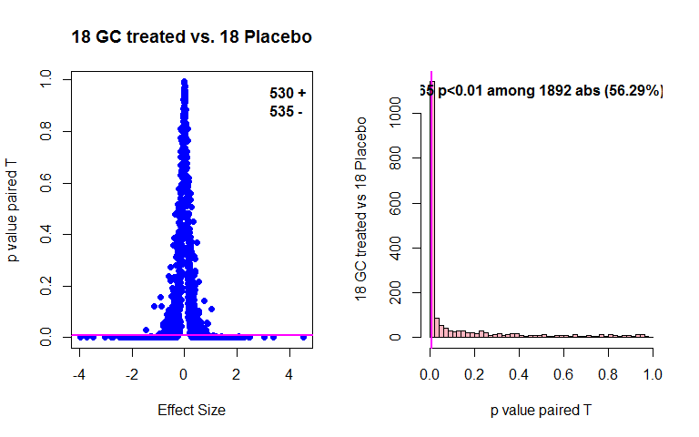

## Statistical Analysis Results -Plan 2

- Moderated T test using R Limma package *Plots*

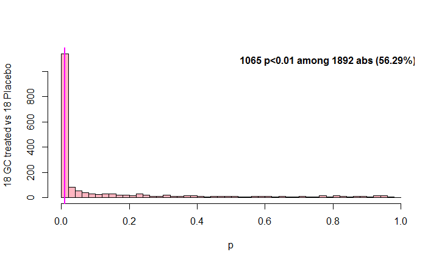

## Statistical Analysis Results -Plan 2

- GSEA using KEGG pathway database and CAMERA

```r
kegg <- getGmt("Data/c2.cp.kegg.v4.0.symbols.gmt")
gene_ids <- geneIds(kegg)
```

```r
if (exists("ids2indices")) {
    sets_indices <- ids2indices(gene_ids, unique.gene)
}
if (exists("symbols2indices")) {
    sets_indices <- symbols2indices(gene_ids, unique.gene)
}
cont_matrix <- makeContrasts("case1", levels = mm)
# gsea <- camera(est_new, sets_indices, design=mm, cont_matrix) It's not working
# due to the NA's So we change all the NA's to zero
est_narm <- est_new
est_narm[is.na(est_narm)] <- 0
gsea_kegg <- camera(est_narm, sets_indices, design = mm, cont_matrix)
```

## Statistical Analysis Results -Plan 2

- GSEA using KEGG pathway database and CAMERA

```r
head(gsea_kegg)
```

```
##                                      NGenes  Correlation Direction
## KEGG_PRION_DISEASES                      18 -0.008346468        Up
## KEGG_ARGININE_AND_PROLINE_METABOLISM      6 -0.103474075      Down
## KEGG_HEMATOPOIETIC_CELL_LINEAGE          38 -0.008397791        Up
## KEGG_ADHERENS_JUNCTION                   28 -0.001979262        Up
## KEGG_WNT_SIGNALING_PATHWAY               63  0.018828167        Up
## KEGG_HUNTINGTONS_DISEASE                 24 -0.011637090        Up
##                                           PValue       FDR
## KEGG_PRION_DISEASES                  0.007455228 0.6167133
## KEGG_ARGININE_AND_PROLINE_METABOLISM 0.012645655 0.6167133
## KEGG_HEMATOPOIETIC_CELL_LINEAGE      0.013293206 0.6167133
## KEGG_ADHERENS_JUNCTION               0.024288061 0.6167133
## KEGG_WNT_SIGNALING_PATHWAY           0.034002868 0.6167133
## KEGG_HUNTINGTONS_DISEASE             0.034243671 0.6167133
```

```r
# now it worked but we don't have anything significant.
```

## Statistical Analysis Results -Plan 2

- GSEA using GO pathway database and CAMERA

```r
go <- getGmt("Data/c5.all.v4.0.symbols.gmt")
gene_ids_go <- geneIds(go)
if (exists("ids2indices")) {
    sets_indices_go <- ids2indices(gene_ids_go, unique.gene)
}
if (exists("symbols2indices")) {
    sets_indices_go <- symbols2indices(gene_ids_go, unique.gene)
}
cont_matrix <- makeContrasts("case1", levels = mm)
gsea_go <- camera(est_narm, sets_indices_go, design = mm, cont_matrix)
```

## Statistical Analysis Results -Plan 2

- GSEA using GO pathway database and CAMERA

```r
head(gsea_go)
```

```
##                                                      NGenes Correlation
## TRANSMEMBRANE_RECEPTOR_PROTEIN_PHOSPHATASE_ACTIVITY       7 -0.08766224
## SH2_DOMAIN_BINDING                                        6 -0.04716995
## MICROTUBULE_CYTOSKELETON_ORGANIZATION_AND_BIOGENESIS      5 -0.07875796
## TRANSLATION                                              19 -0.02595779
## CHROMOSOMEPERICENTRIC_REGION                              5 -0.11868969
## INTRA_GOLGI_VESICLE_MEDIATED_TRANSPORT                    3 -0.09631550
##                                                      Direction
## TRANSMEMBRANE_RECEPTOR_PROTEIN_PHOSPHATASE_ACTIVITY         Up
## SH2_DOMAIN_BINDING                                        Down
## MICROTUBULE_CYTOSKELETON_ORGANIZATION_AND_BIOGENESIS      Down
## TRANSLATION                                                 Up
## CHROMOSOMEPERICENTRIC_REGION                              Down
## INTRA_GOLGI_VESICLE_MEDIATED_TRANSPORT                      Up
##                                                            PValue
## TRANSMEMBRANE_RECEPTOR_PROTEIN_PHOSPHATASE_ACTIVITY  0.0009027658
## SH2_DOMAIN_BINDING                                   0.0030514097
## MICROTUBULE_CYTOSKELETON_ORGANIZATION_AND_BIOGENESIS 0.0055538195
## TRANSLATION                                          0.0062537782
## CHROMOSOMEPERICENTRIC_REGION                         0.0080958757
## INTRA_GOLGI_VESICLE_MEDIATED_TRANSPORT               0.0085751646
##                                                            FDR
## TRANSMEMBRANE_RECEPTOR_PROTEIN_PHOSPHATASE_ACTIVITY  0.9932556
## SH2_DOMAIN_BINDING                                   0.9932556
## MICROTUBULE_CYTOSKELETON_ORGANIZATION_AND_BIOGENESIS 0.9932556
## TRANSLATION                                          0.9932556
## CHROMOSOMEPERICENTRIC_REGION                         0.9932556
## INTRA_GOLGI_VESICLE_MEDIATED_TRANSPORT               0.9932556
```

```r
# also nothing significant!
```

## Limitation

- Small sample size
- Only detecting proteints that have antibodies on the microarray

## Conclusion and Discussion

- Results for individual proteins are similar
- Results for pathway analysis are very different.

**Why?** - We set all missing values to 0 - Different methods: paired t-test vs. LIMMA; Wilcoxon test vs. CAMERA